# Homework #3 Key

Grammar of Graphics

Due: 15 Jan 2020

## Concepts

Define and explain each of the seven parts of the layered grammar of graphics.

Data: identifies the primary data set that provides the data for the graph.

Aethetics: the assignment of x-axis, y-axis, color, fill, stroke, linetype, shape, size, and transparency to variables in the data frame. This is a set of mappings.

Geoms: Creates a series of layers which contain a type of graph.

Stats: Some types of graphs require calculations before the graph can be drawn. For example, geom_smooth requires the calculation of loess or other types of smoothing such as simple linear regression. The geom_bar requires counting the frequency of each category in the variable.

Position: alters the presentation of the data. The geom_bar can have position of identity, fill, or dodge. In order to show all points in a scatterplot, we use the geom_scatter or us a position = “jitter” in the geom_point part of the function call.

Coordinate System: Changes the coordinate system. The coord_flip swaps the x and y axes. It can also be used to change from the default cartesian to polor coordinates.

Facet: Creates a separate graph for each value in a categorical variable or a separate graph for a range of values for numerical variables. This might also be seen as splitting a graph into subplots.

## Interpretation of code

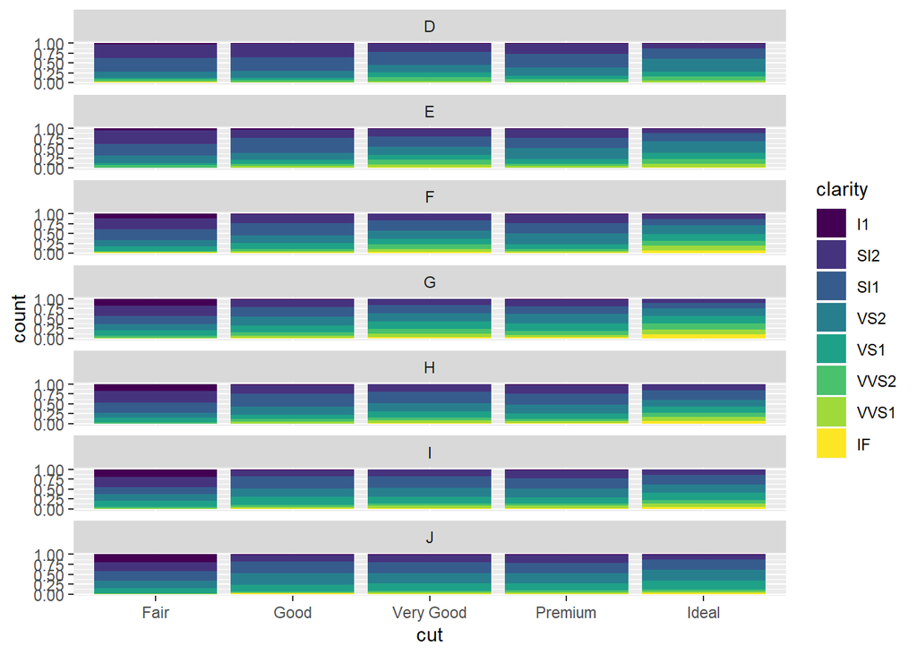

```r
ggplot(data = diamonds, mapping = aes(x = cut, fill = clarity)) +
  geom_bar(position = "fill") +
  facet_wrap(vars(color), ncol = 1)
```

Line 1: sets up the regular ggplot parameters by identifying the data set. The categorical variable cut is identified as the variable that is being analyzed.

Line 2: Creates a layer that includes a bar chart. From the first line, the color of each bar is determined by the clarity categorical variable. The position = “fill” means that the proportion of each clarity category rather than counts are given for each clarity category.

Line 3: Creates a separate bar chart for each value of the color variable. There is only one column so the bar charts are stacked one above the other.

## Using the mpg tibble, draw a proportional bar chart for class of vehicle (class), drive train (drv), and year

1. Put class on the x axis.
2. Color the bars based on the drive.
3. Use position to convert the proportional bar chart.
4. Use facet_grid to create a graph for 1999 and 2008.

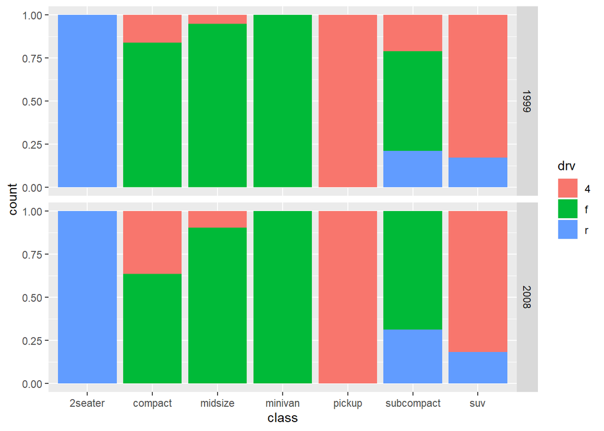

```r
ggplot(data = mpg, mapping = aes(x = class, fill = drv)) +
  geom_bar(position = "fill") +
  facet_grid(rows = vars(year))
```